# Data_visualization

Ian Greaves

8 August 2018

# Data:

For this task I’ve decided to use the legumes data set. The data is as follows

‘Rhizobes’, i.e. bacteria living on plant roots, can increase plant growth. This dataset investigates the effect of different rhizobial strains on legume growth. Variable are as follows:

**Block:** independent experimental ‘block’

**Plant:** plant species (Ad: Acacia dealbata; Am: Acacia mearnsii; Dm: Daviesia mimosoides; Gc: Glycine clandestina; Hv: Hardenbergia violacea; Oe: Oxylobium ellipticum)

**Strain:** rhizobial strain (note: values are descriptive strain identifiers, not quantitative measures) 20 strains in total

**Weight:** plant weight at conclusion of experiment.

## Setting up environment

Loading library dplyr

```r
library(tidyverse)
```

## Adding in data

```r
Legumes <- read_csv(file = "data/legume_weights_rhizobia_20str.csv")
Legumes
```

```
## # A tibble: 1,200 x 4
##    Block Plant Strain weight
##    <chr> <chr>  <int>  <dbl>
##  1 A     Ad      1075   3.27
##  2 B     Ad      1075   1.85
##  3 C     Ad      1075   3.36
##  4 D     Ad      1075   1.92
##  5 E     Ad      1075   2.17
##  6 V     Ad      1075   2.53
##  7 W     Ad      1075   2.44
##  8 X     Ad      1075   2.05
##  9 Y     Ad      1075   2.37
## 10 Z     Ad      1075   0.81
## # ... with 1,190 more rows
```

## Make Data tidy

Will make the data tidy by combining the first 3 lists to make a unique identifier. Will retain all the lists for visualization

```r
Legumes1 <- Legumes %>%
  unite(Identifier,Block, Plant, Strain, sep = "_")
Legumes1
```

```
## # A tibble: 1,200 x 2
##    Identifier weight
##    <chr>       <dbl>
##  1 A_Ad_1075    3.27
##  2 B_Ad_1075    1.85
##  3 C_Ad_1075    3.36
##  4 D_Ad_1075    1.92
##  5 E_Ad_1075    2.17
##  6 V_Ad_1075    2.53
##  7 W_Ad_1075    2.44
##  8 X_Ad_1075    2.05
##  9 Y_Ad_1075    2.37
## 10 Z_Ad_1075    0.81
## # ... with 1,190 more rows
```

That didn’t work so I will try mutate instead

```r
Legumes = mutate(Legumes,
   Identifier = paste(Block, Plant, Strain, sep = '_'))
Legumes <- Legumes[,c(5,1:4)]
Legumes
```

```
## # A tibble: 1,200 x 5
##    Identifier Block Plant Strain weight
##    <chr>      <chr> <chr>  <int>  <dbl>
##  1 A_Ad_1075  A     Ad      1075   3.27
##  2 B_Ad_1075  B     Ad      1075   1.85
##  3 C_Ad_1075  C     Ad      1075   3.36
##  4 D_Ad_1075  D     Ad      1075   1.92
##  5 E_Ad_1075  E     Ad      1075   2.17
##  6 V_Ad_1075  V     Ad      1075   2.53
##  7 W_Ad_1075  W     Ad      1075   2.44
##  8 X_Ad_1075  X     Ad      1075   2.05
##  9 Y_Ad_1075  Y     Ad      1075   2.37
## 10 Z_Ad_1075  Z     Ad      1075   0.81
## # ... with 1,190 more rows
```

## Initial Analysis

Look at the overall data.

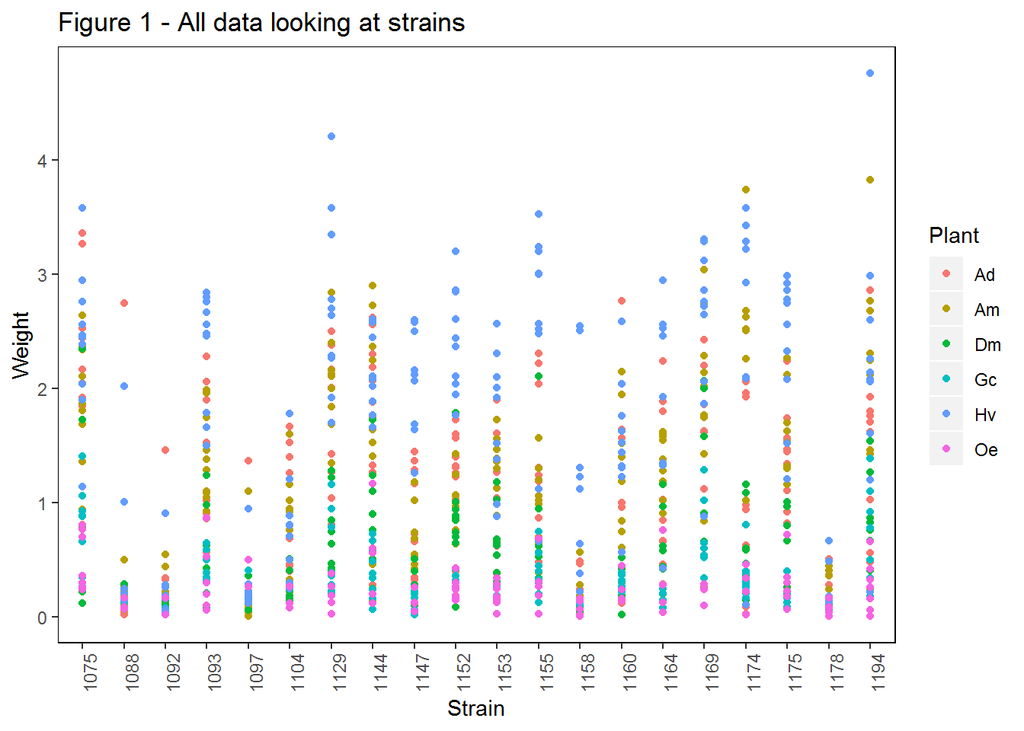

```r
ggplot(data = Legumes,
       aes(x = as.factor(Strain), y = weight, colour = Plant)) +
  geom_point() +
  labs(
    x = "Strain",
    y = "Weight",
    title = "Figure 1 - All data looking at strains",
    colour = "Plant"
  ) +
  theme(
    panel.grid=element_blank(),
    axis.text.x = element_text(angle=90),
    panel.background = element_rect(fill = "white",
                                    colour = "black")
    )
```

Change the grouping to Plant and see if the scatter plot can quickly show which strain was best for each plant

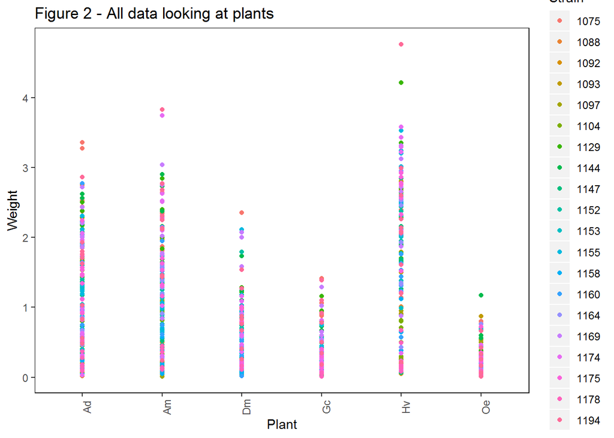

```r
ggplot(data = Legumes,
       aes(x = Plant, y = weight, colour = as.factor(Strain))) +
  geom_point() +
  labs(
    x = "Plant",
    y = "Weight",
    title = "Figure 2 - All data looking at plants",
    colour = "Strain"
  ) +
  theme(
    panel.grid=element_blank(),
    axis.text.x = element_text(angle=90),
    panel.background = element_rect(fill = "white",
                                    colour = "black")
    )
```

Plot all the data together

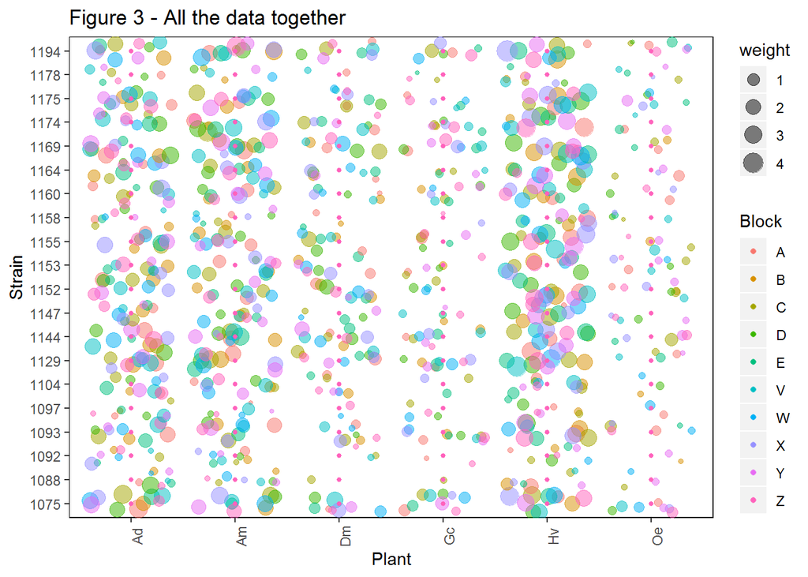

```r
ggplot(data = Legumes,
       aes(x = Plant, y = as.factor(Strain), colour = Block, size = weight)) +
  geom_jitter(alpha = 0.5)+
  geom_point(size =1) +

  labs(
    x = "Plant",
    y = "Strain",
    title = "Figure 3 - All the data together",
    colour = "Block",
    size = "weight"
  ) +
  theme(
    panel.grid=element_blank(),
    axis.text.x = element_text(angle=90),
    panel.background = element_rect(fill = "white",
                                    colour = "black")
    )
```

Would like to look and see if there is any variation between blocks

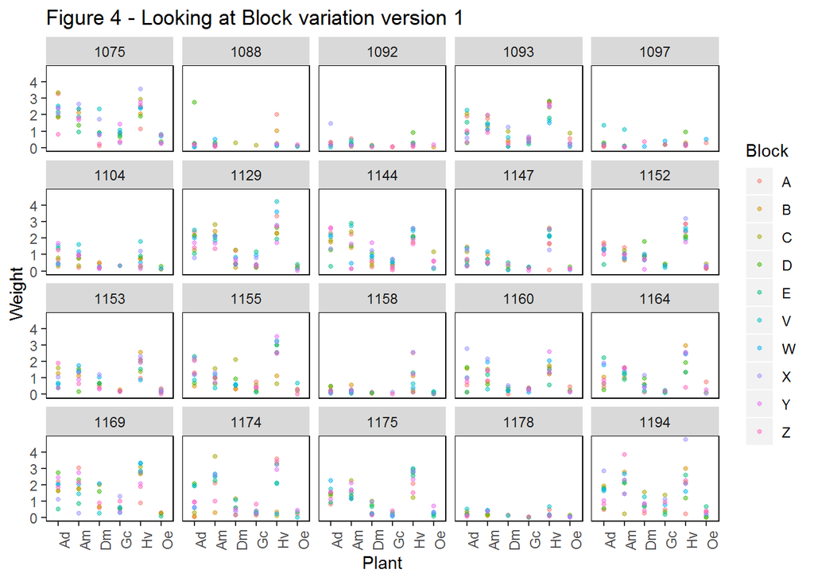

```r
ggplot(data = Legumes,
       aes(x = Plant, y = weight, colour = Block)) +
  geom_point(size =1, alpha = 0.5) +
  facet_wrap(~ Strain) +
  labs(
    x = "Plant",
    y = "Weight",
    title = "Figure 4 - Looking at Block variation version 1",
    colour = "Block"
  ) +
  theme(
    panel.grid=element_blank(),
    axis.text.x = element_text(angle=90),
    panel.background = element_rect(fill = "white",
                                    colour = "black")
    )
```

Another look at block variation

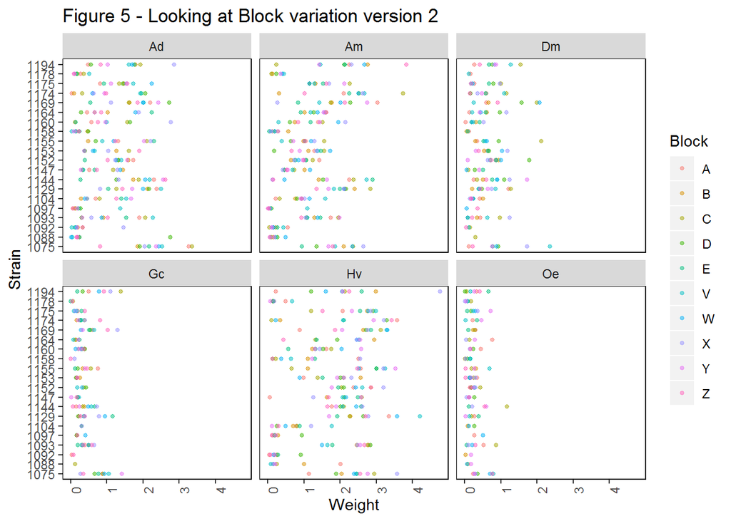

```r
ggplot(data = Legumes,
       aes(x = weight, y = as.factor(Strain), colour = Block)) +
  geom_point(size =1, alpha = 0.5) +
  facet_wrap(~ Plant) +
  labs(
    x = "Weight",
    y = "Strain",
    title = "Figure 5 - Looking at Block variation version 2",
    colour = "Block"
  ) +
  theme(
    panel.grid=element_blank(),
    axis.text.x = element_text(angle=90),
    panel.background = element_rect(fill = "white",
                                    colour = "black")
    )
```

Wanted to know which strain was best in each line. So facet wrapped on PLant with the x axis as strain.

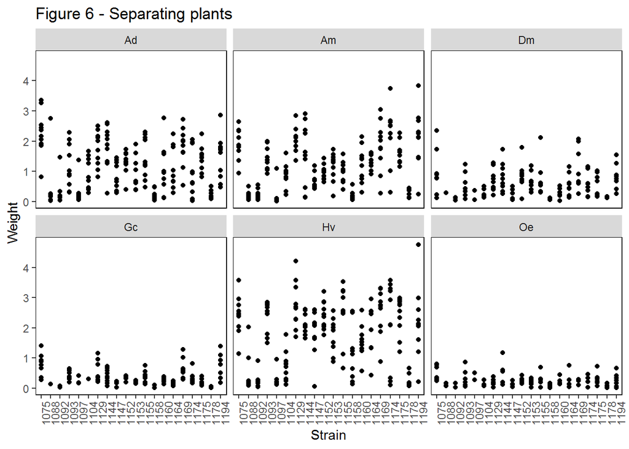

```r
ggplot(data = Legumes,
       aes(x = as.factor(Strain), y = weight)) +
  geom_point() +
  facet_wrap(~ Plant) +
  labs(
    x = "Strain",
    y = "Weight",
    title = "Figure 6 - Separating plants",
    colour = "Plant"
  ) +
  theme(
    panel.grid=element_blank(),
    axis.text.x = element_text(angle=90),
    panel.background = element_rect(fill = "white",
                                    colour = "black")
    )
```

## CONCLUSION

There are some strains which increase plant size over others. For example 1075 seems to work well in a number of varieties. There is big differences in plant size.

Would have liked to compared plant size against control lines.

## Stuff NOT to do

To get a feel how each plant has done with each strain I/m giong to use dplyr group by to group by plant and strain and use mean to xummarize the weights. Data contains NA’s so will remove them.

```r
Legumes_Av <-Legumes %>%
  drop_na() %>%
    group_by(Plant, Strain) %>%
    summarise(mean_weight=mean(weight), n=n(), sd = sd(weight),se=sd/sqrt(n))

Legumes_Av
```

```
## # A tibble: 120 x 6
## # Groups:   Plant [?]
##    Plant Strain mean_weight     n    sd    se
##    <chr>  <int>       <dbl> <int> <dbl> <dbl>
##  1 Ad      1075       2.28     10 0.729 0.231
##  2 Ad      1088       0.484     8 0.920 0.325
##  3 Ad      1092       0.355     8 0.457 0.162
##  4 Ad      1093       1.18     10 0.724 0.229
##  5 Ad      1097       0.305     8 0.437 0.154
##  6 Ad      1104       0.895    10 0.521 0.165
##  7 Ad      1129       1.74     10 0.583 0.184
##  8 Ad      1144       1.82     10 0.710 0.225
##  9 Ad      1147       0.816    10 0.460 0.146
## 10 Ad      1152       1.28     10 0.372 0.118
## # ... with 110 more rows
```

Boxplot of the data

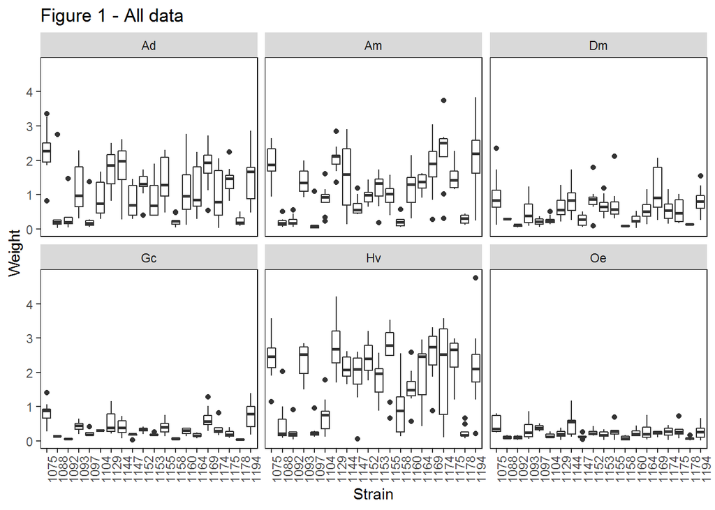

```r
ggplot(data = Legumes,
       aes(x = as.factor(Strain), y = weight)) +
  geom_boxplot() +
  facet_wrap(~ Plant) +
  labs(
    x = "Strain",
    y = "Weight",
    title = "Figure 1 - All data",
    colour = "Plant"
  ) +
  theme(
    panel.grid=element_blank(),
    axis.text.x = element_text(angle=90),
    panel.background = element_rect(fill = "white",
                                    colour = "black")
    )
```